# How to orginze perfect lottery where people never win anything - Amino KasaRomana

Maciej Nasinski

2020-12-09

In Poland there is a very popular lottery organized by a Amino food company named Kasa Romana.  
It was established first time in 90’s and the last attempt known by me in the 2016.  
There were gathered a sufficient data about it because of the YouTube channel which testing certain products in thousands during some promations.  
[BezKanalu YouTube channel](https://www.facebook.com/BezKanalu/) brought precisely 1002 coupons from last event.  
The main objectives are to find patterns for this data and make sure if the coupons give any chance to win some real money.  
The main rule is that people could win money if the have a set of coupons which sum to full hundreds (100, 200, …) up to 1000.  
The knapsack algorithm was used to check if there are some combinations of coupons which enable to win some money.  
All processing is done from R programming environment.

Loading the data:

```r
coupons = as.numeric(readLines("./knapsack.txt"))

head(coupons, 30)
```

```
##  [1] 455 650  26 464  26 750 490 520 399 390 750 455 104 260  26 438 633 455 195
## [20] 516 598 481 299 724 243  26 533 455 572 208
```

Sorted table of frequencies:

```r
sort(table(coupons))
```

```
## coupons
## 334 403 646 204 208 360 507 620 104 234 364 481 633 698 143 247 256 269 373 377
##   1   1   1   2   2   2   2   2   3   3   3   3   3   3   4   4   4   4   4   4
## 429 468 490 581 607 217 286 308 386 451 464 494 594 672 685 711 156 165 169 182
##   4   4   4   4   4   5   5   5   5   5   5   5   5   5   5   5   6   6   6   6
## 221 282 299 325 399 503 559 637 724  65  91 191 230 321 338 351 416 477 516 529
##   6   6   6   6   6   6   6   6   6   7   7   7   7   7   7   7   7   7   7   7
## 568 572 585 611 624 659 737 117 195 295 312 347  78 273 425 442 533 542 546 555
##   7   7   7   7   7   7   7   8   8   8   8   8   9   9   9   9   9   9   9   9
## 598  39  52 520 438 243 412 650 130 390 260 455 750  26
##   9  10  10  10  11  12  13  50  57  57  61  71  90  95
```

Histrogram might be helpful to find certain patterns:

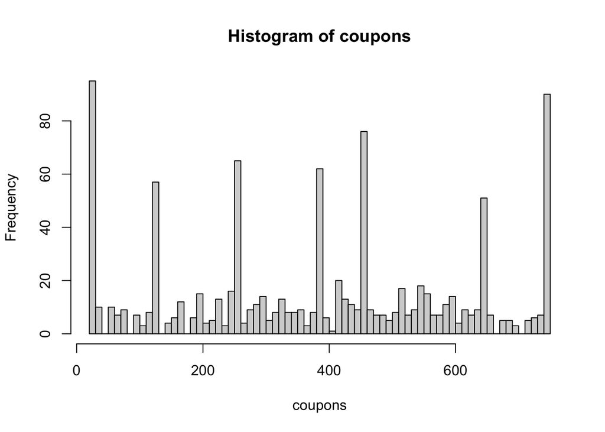

```r
hist(coupons,breaks=100)
```

**Numbers seems to be generated from 2 specific patterns:**

- multiplication of 13 starting from 26
- multiplication of 13 plus 165

```r
rep13 = sapply(1:52, function(x) 13*x)

rep2_13 = sapply(0:45, function(x) 165 + (13*x))

all(coupons %in% c(rep13, rep2_13))
```

```
## [1] TRUE
```

All of our coupons comes from this 2 sequences.

Compering coupons with artificially generated ones form two presented sequences.

```r
a = sort(c(unique(coupons),178)) # one coupon has to be added 165 + 13
b = sort(c(sapply(0:45,function(x) 165+(13*x)),sapply(2:50,function(x) (13*x))))

both = data.frame(real = a, generated = b)

head(both)
```

```
##   real generated
## 1   26        26
## 2   39        39
## 3   52        52
## 4   65        65
## 5   78        78
## 6   91        91
```

```r
tail(both)
```

```
##    real generated
## 90  685       685
## 91  698       698
## 92  711       711
## 93  724       724
## 94  737       737
## 95  750       750
```

*Single knapsack problem:*

Knapsack is an optimization method, linear programming for integers.

```r
library(adagio)

cupon_we_have = rep(both$generated,100)

cupon_we_want = seq(100,1000,100)

for(i in cupon_we_want){

solution <- try(knapsack(p=cupon_we_have[cupon_we_have<i], w=cupon_we_have[cupon_we_have<i], cap=i))

print(solution$profit)
}
```

```
## [1] 91
## [1] 195
## [1] 299
## [1] 399
## [1] 499
## [1] 599
## [1] 699
## [1] 798
## [1] 898
## [1] 998
```

Taking into account only coupons provided there is no chance to win anything.  
This seems to no be surprising when we know from what sequences the coupons come from.  
The question is about potential existence of other coupons which might enable to win something.